# Film Oneri Sistemleri

Grup 8

**Serenay Akciyer 121516030**

**Nisanur Topraç 121516026**

## Projeye Genel Bakis

Bu projede, film onermek icin ortak bir filtreleme tavsiye (CFR) sistemi gelistirmek amaslanmistir.

CFR sistemlerinin temel fikri, eger iki kullanici gecmiste ayni ilgi alanlarini paylasiyorsa,(ornegin ayni kitabi veya ayni filmi sevdiler) gelecekte de benzer zevklere sahip olacaklardir. Ornegin, A kullanicisi ve B kullanicisi benzer bir kitap satin alma gecmisine sahipse ve A kullanicisi yakin zamanda B kullanicisinin henuz gormedigi bir kitap satin aldiysa, temel fikir bu kitabi B kullanicisina onermektir.

Bu projede, film onermek icin herkese acik bir film derecelendirme veri kumesinden filmlere yonelik cok sayida kullanici tercihi iceren veri seti kullanilmistir.

## Kullanilan Kutuphaneler

Bu projede asagidaki kutuphaneler kullanilmistir:

- **recommenderlab:** Tavsiye Algoritmalarini gelistirme ve test etme kutuphanesidir.
- **ggplot2:** Gorsellestirme ve grafiklerin cizimi.
- **data.table:** Buyuk verilerin hizli bir sekilde toplanmasi,hizli sirali birlestirmeler,gruplara sutun ekleme,karakterlerle ayrilmis deger okuma yazma vb. islevler icin kullanilan kutuphanedir.
- **reshape2:** Genis ve uzun formatlar arasinda veri donusturmeyi kolaylastiran pakettir.

```r
library(recommenderlab)
library(ggplot2)
library(data.table)
library(reshape2)
```

## Veri Kumesi

Kullanilan veri seti grouplens.org'tadir ve http://grouplens.org/datasets/movielens/latest adresinde herkese aciktir. Bu veriler 03 Nisan 1996 ve 09 Ocak 2016 arasinda 668 kullanici tarafindan olusturuldu. Veri kumesi ise 11 Ocak 2016'da olusturulmustur.

```r
movies <- read.csv("movies.csv",stringsAsFactors=FALSE)
ratings <- read.csv("ratings.csv")
```

*movies* icerigi, verinin ilk birkac satiri ile birlikte asagida verilmistir:

```r
summary(movies)
```

```
##     movieId          title              genres
##  Min.   :     1   Length:10329       Length:10329
##  1st Qu.:  3240   Class :character   Class :character
##  Median :  7088   Mode  :character   Mode  :character
##  Mean   : 31924
##  3rd Qu.: 59900
##  Max.   :149532
```

```r
head(movies)
```

|  | movieId | title | genres |
| --- | --- | --- | --- |
| 1 | 1 | Toy Story (1995) | Adventure\|Animation\|Children\|Comedy\|Fantasy |
| 2 | 2 | Jumanji (1995) | Adventure\|Children\|Fantasy |
| 3 | 3 | Grumpier Old Men (1995) | Comedy\|Romance |
| 4 | 4 | Waiting to Exhale (1995) | Comedy\|Drama\|Romance |
| 5 | 5 | Father of the Bride Part II (1995) | Comedy |
| 6 | 6 | Heat (1995) | Action\|Crime\|Thriller |

*ratings* icerigi, verinin ilk birkac satiri ile birlikte asagida verilmistir:

```r
summary(ratings)
```

```
##      userId         movieId           rating        timestamp
##  Min.   :  1.0   Min.   :     1   Min.   :0.500   Min.   :8.286e+08
##  1st Qu.:192.0   1st Qu.:  1073   1st Qu.:3.000   1st Qu.:9.711e+08
##  Median :383.0   Median :  2497   Median :3.500   Median :1.115e+09
##  Mean   :364.9   Mean   : 13381   Mean   :3.517   Mean   :1.130e+09
##  3rd Qu.:557.0   3rd Qu.:  5991   3rd Qu.:4.000   3rd Qu.:1.275e+09
##  Max.   :668.0   Max.   :149532   Max.   :5.000   Max.   :1.452e+09
```

```r
head(ratings)
```

|  | userId | movieId | rating | timestamp |
| --- | --- | --- | --- | --- |
| 1 | 1 | 16 | 4.0 | 1217897793 |
| 2 | 1 | 24 | 1.5 | 1217895807 |
| 3 | 1 | 32 | 4.0 | 1217896246 |
| 4 | 1 | 47 | 4.0 | 1217896556 |
| 5 | 1 | 50 | 4.0 | 1217896523 |
| 6 | 1 | 110 | 4.0 | 1217896150 |

## Veri On Isleme

Ilk once film turlerinin bilgileri, gelecekteki kullanicilarin belirli turlerde sevdikleri filmleri aramasina izin verilecek sekilde yeniden duzenlenir.

## Tur Listesi Cikarma

Her film icin karsilik gelen turlerin bir matrisi olusturulur.

```r
genres <- as.data.frame(movies$genres, stringsAsFactors=FALSE)

genres2 <- as.data.frame(tstrsplit(genres[,1], '[|]',
                                   type.convert=TRUE),
                         stringsAsFactors=FALSE)
colnames(genres2) <- c(1:10)

genre_list <- c("Action", "Adventure", "Animation", "Children",
                "Comedy", "Crime","Documentary", "Drama", "Fantasy",
                "Film-Noir", "Horror", "Musical", "Mystery","Romance",
                "Sci-Fi", "Thriller", "War", "Western") # 18 tane film turu vardir

genre_matrix <- matrix(0,10330,18) #bos matris, 10330= film sayisi +1, 18= tur sayisi
genre_matrix[1,] <- genre_list # ilk satiri tur listesine ayarla
colnames(genre_matrix) <- genre_list #tur listesine sutun adlarini ayarlama

# matris araciligiyla yineleme

for (i in 1:nrow(genres2)) {
  for (c in 1:ncol(genres2)) {
    genmat_col = which(genre_matrix[1,] == genres2[i,c])
    genre_matrix[i+1,genmat_col] <- 1
  }
}

# veri tablosuna donusturmek
genre_matrix2 <- as.data.frame(genre_matrix[-1,], stringsAsFactors=FALSE) #tur listesi olan ilk satiri kaldirmak
for (c in 1:ncol(genre_matrix2)) {
  genre_matrix2[,c] <- as.integer(genre_matrix2[,c])  #karakterlerden tam sayilara donusturme
}

head(genre_matrix2)
```

|  | Action | Adventure | Animation | Children | Comedy | Crime | Documentary | Drama | Fantasy | Film-Noir | Horror | Musical | Mystery | Romance | Sci-Fi | Thriller | War | Western |
| --- | --- | --- | --- | --- | --- | --- | --- | --- | --- | --- | --- | --- | --- | --- | --- | --- | --- | --- |
| 1 | 0 | 1 | 1 | 1 | 1 | 0 | 0 | 0 | 1 | 0 | 0 | 0 | 0 | 0 | 0 | 0 | 0 | 0 |
| 2 | 0 | 1 | 0 | 1 | 0 | 0 | 0 | 0 | 1 | 0 | 0 | 0 | 0 | 0 | 0 | 0 | 0 | 0 |
| 3 | 0 | 0 | 0 | 0 | 1 | 0 | 0 | 0 | 0 | 0 | 0 | 0 | 0 | 1 | 0 | 0 | 0 | 0 |
| 4 | 0 | 0 | 0 | 0 | 1 | 0 | 0 | 1 | 0 | 0 | 0 | 0 | 0 | 1 | 0 | 0 | 0 | 0 |
| 5 | 0 | 0 | 0 | 0 | 1 | 0 | 0 | 0 | 0 | 0 | 0 | 0 | 0 | 0 | 0 | 0 | 0 | 0 |
| 6 | 1 | 0 | 0 | 0 | 0 | 1 | 0 | 0 | 0 | 0 | 0 | 0 | 0 | 0 | 0 | 1 | 0 | 0 |

## Bir Ture Gore Film Aramak Icin Matris Olusturmak

Bir filmin turune gore kolayca aranmasini saglayacak *search matrix* olusturulur.

```r
search_matrix <- cbind(movies[,1:2], genre_matrix2)
head(search_matrix)
```

|  | movieId | title | Action | Adventure | Animation | Children | Comedy | Crime | Documentary | Drama | Fantasy | Film-Noir | Horror | Musical | Mystery | Romance | Sci-Fi | Thriller | War | Western |
| --- | --- | --- | --- | --- | --- | --- | --- | --- | --- | --- | --- | --- | --- | --- | --- | --- | --- | --- | --- | --- |
| 1 | 1 | Toy Story (1995) | 0 | 1 | 1 | 1 | 1 | 0 | 0 | 0 | 1 | 0 | 0 | 0 | 0 | 0 | 0 | 0 | 0 | 0 |
| 2 | 2 | Jumanji (1995) | 0 | 1 | 0 | 1 | 0 | 0 | 0 | 0 | 1 | 0 | 0 | 0 | 0 | 0 | 0 | 0 | 0 | 0 |
| 3 | 3 | Grumpier Old Men (1995) | 0 | 0 | 0 | 0 | 1 | 0 | 0 | 0 | 0 | 0 | 0 | 0 | 0 | 1 | 0 | 0 | 0 | 0 |
| 4 | 4 | Waiting to Exhale (1995) | 0 | 0 | 0 | 0 | 1 | 0 | 0 | 1 | 0 | 0 | 0 | 0 | 0 | 1 | 0 | 0 | 0 | 0 |
| 5 | 5 | Father of the Bride Part II (1995) | 0 | 0 | 0 | 0 | 1 | 0 | 0 | 0 | 0 | 0 | 0 | 0 | 0 | 0 | 0 | 0 | 0 | 0 |
| 6 | 6 | Heat (1995) | 1 | 0 | 0 | 0 | 0 | 1 | 0 | 0 | 0 | 0 | 0 | 0 | 0 | 0 | 0 | 1 | 0 | 0 |

Her filmin bir veya birden fazla ture karsilik geldigi gorulur.

## Derecelendirme Matrisini Uygun Bicimde Donusturme

*Recommenderlab* ile bir oneri motoru olusturmak ve derecelendirme verilerini kullanmak icin, derecelendirme matrisi *realRatingMatrix* turundeki tavsiye edici seyrek matrise donusturulur.

```r
#Derecelendirme matrisi. Satirlar = userId, Sutunlar = movieId
ratingmat <- dcast(ratings, userId~movieId, value.var = "rating", na.rm=FALSE)
ratingmat <- as.matrix(ratingmat[,-1]) # userIds kaldirmak

#Derecelendirme matrisini tavsiye edici bir seyrek matrise donusturme
ratingmat <- as(ratingmat, "realRatingMatrix")
ratingmat
```

```
## 668 x 10325 rating matrix of class 'realRatingMatrix' with 105339 ratings.
```

## Oneri Modellerinin Parametreleri

*Recommenderlab* paketi, oneri algoritmasi icin bazi secenekler icerir:

```r
recommender_models <- recommenderRegistry$get_entries(dataType = "realRatingMatrix")
names(recommender_models)
```

```
##  [1] "HYBRID_realRatingMatrix"       "ALS_realRatingMatrix"
##  [3] "ALS_implicit_realRatingMatrix" "IBCF_realRatingMatrix"
##  [5] "LIBMF_realRatingMatrix"        "POPULAR_realRatingMatrix"
##  [7] "RANDOM_realRatingMatrix"       "RERECOMMEND_realRatingMatrix"
##  [9] "SVD_realRatingMatrix"          "SVDF_realRatingMatrix"
## [11] "UBCF_realRatingMatrix"
```

```r
lapply(recommender_models, "[[", "description")
```

```
## $HYBRID_realRatingMatrix
## [1] "Hybrid recommender that aggegates several recommendation strategies using weighted averages."
##
## $ALS_realRatingMatrix
## [1] "Recommender for explicit ratings based on latent factors, calculated by alternating least squares algorithm."
##
## $ALS_implicit_realRatingMatrix
## [1] "Recommender for implicit data based on latent factors, calculated by alternating least squares algorithm."
##
## $IBCF_realRatingMatrix
## [1] "Recommender based on item-based collaborative filtering."
##
## $LIBMF_realRatingMatrix
## [1] "Matrix factorization with LIBMF via package recosystem (https://cran.r-project.org/web/packages/recosystem/vignettes/introduction.html)."
##
## $POPULAR_realRatingMatrix
## [1] "Recommender based on item popularity."
##
## $RANDOM_realRatingMatrix
## [1] "Produce random recommendations (real ratings)."
##
## $RERECOMMEND_realRatingMatrix
## [1] "Re-recommends highly rated items (real ratings)."
##
## $SVD_realRatingMatrix
## [1] "Recommender based on SVD approximation with column-mean imputation."
##
## $SVDF_realRatingMatrix
## [1] "Recommender based on Funk SVD with gradient descend (https://sifter.org/~simon/journal/20061211.html)."
##
## $UBCF_realRatingMatrix
## [1] "Recommender based on user-based collaborative filtering."
```

**HYBRID_realRatingMatrix :** Agirlikli ortalamalar kullanarak cesitli oneri stratejilerini toplayan hibrit tavsiye.

**ALS_realRatingMatrix :** Alternatif en kucuk kareler algoritmasi ile hesaplanan gizli faktorlere dayali acik derecelendirmeler icin oneri.

**ALS_implicit_realRatingMatrix :** Degisken en kucuk kareler algoritmasi ile hesaplanan gizli faktorlere dayali ortuk veriler icin tavsiye.

**IBCF_realRatingMatrix :** Ogeye baglı ortak calismaya dayali filtrelemeye yontemi.

**LIBMF_realRatingMatrix :** Paket recosystem uzerinden LIBMF ile matris carpanlarina ayirma

**POPULAR_realRatingMatrix :** Tavsiye oge populerligine gore.

**RANDOM_realRatingMatrix :** Rastgele oneriler uretin (gercek derecelendirmeler).

**RERECOMMEND_realRatingMatrix :** Yuksek puan alan ogeleri (gercek puanlar) yeniden onerir.

**SVD_realRatingMatrix :** Sutun ortalama gosterimiyle SVD yaklasimina dayanan oneri.

**SVDF_realRatingMatrix :** Degrade inisli Funk SVD'yi temel alan oneri.

**UBCF_realRatingMatrix :** Kullanici tabanli ortak calismaya dayali filtreleme onerisi.

Bu projede IBCF_realRatingMatrix ve UBCF_realRatingMatrix kullanilacaktir. Bu iki modelin parametreleri kontrol edilir.

```r
recommender_models$IBCF_realRatingMatrix$parameters
```

```
## $k
## [1] 30
##
## $method
## [1] "Cosine"
##
## $normalize
## [1] "center"
##
## $normalize_sim_matrix
## [1] FALSE
##
## $alpha
## [1] 0.5
##
## $na_as_zero
## [1] FALSE
```

```r
recommender_models$UBCF_realRatingMatrix$parameters
```

```
## $method
## [1] "cosine"
##
## $nn
## [1] 25
##
## $sample
## [1] FALSE
##
## $weighted
## [1] TRUE
##
## $normalize
## [1] "center"
##
## $min_matching_items
## [1] 0
##
## $min_predictive_items
## [1] 0
```

## Benzerlik Verilerini Kesfetme

Isbirlikci filtreleme algoritmalari, kullanicilar veya ogeler arasindaki benzerligin olculmesine dayanir. Bu amacla, *recommenderlab* benzerlik fonksiyonu icerir. Benzerlikleri hesaplamak icin desteklenen yontemler *cosine, pearson* ve *jaccard*'dir.

*cosine* yani kosinus mesafesi kullanilarak benzerlik matrisi olusturulmustur. Daha sonra bu matris gorsellestirilerek ilk 4 kullanicinin birbirine ne kadar benzedigi belirlenmistir.

```r
similarity_users <- similarity(ratingmat[1:4, ],
                               method = "cosine",
                               which = "users")
as.matrix(similarity_users)
```

```
##           1         2         3         4
## 1 0.0000000 0.9760860 0.9641723 0.9914398
## 2 0.9760860 0.0000000 0.9925732 0.9374253
## 3 0.9641723 0.9925732 0.0000000 0.9888968
## 4 0.9914398 0.9374253 0.9888968 0.0000000
```

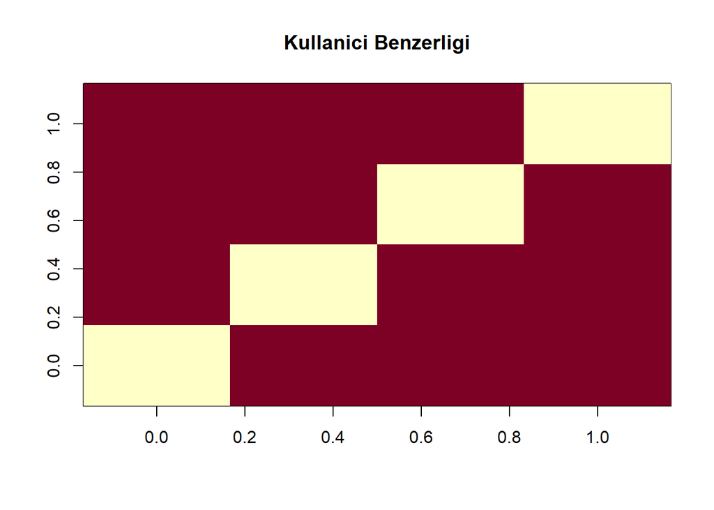

```r
image(as.matrix(similarity_users), main = "Kullanici Benzerligi")
```

Verilen matriste, her satir ve her sutun bir kullaniciya karsilik gelir ve her hucre iki kullanici arasindaki benzerlige karsilik gelir. Hucre ne kadar kirmizi olursa, iki kullanici da o kadar benzerdir.

Ayni yaklasim kullanilarak ilk dort film arasindaki benzerlik hesaplanir.

```r
similarity_items <- similarity(ratingmat[, 1:4], method =
                                 "cosine", which = "items")
as.matrix(similarity_items)
```

```
##           1         2         3         4
## 1 0.0000000 0.9669732 0.9559341 0.9101276
## 2 0.9669732 0.0000000 0.9658757 0.9412416
## 3 0.9559341 0.9658757 0.0000000 0.9864877
## 4 0.9101276 0.9412416 0.9864877 0.0000000
```

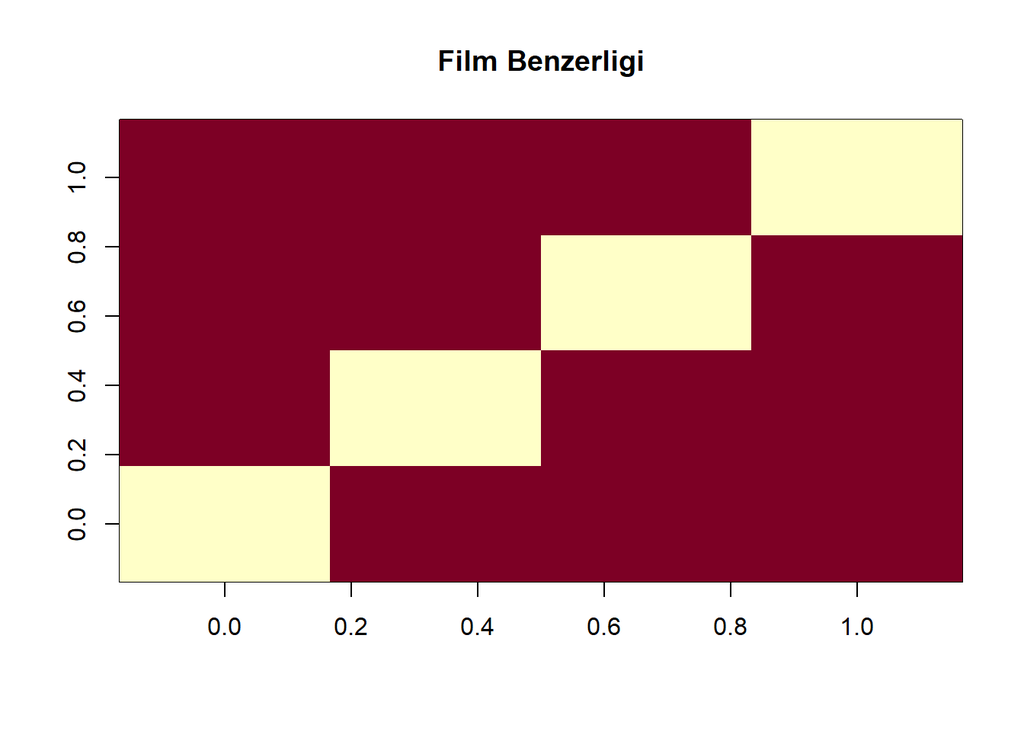

```r
image(as.matrix(similarity_items), main = "Film Benzerligi")
```

## Derecelendirme Degerleri Arastirilir

```r
vector_ratings <- as.vector(ratingmat@data)
unique(vector_ratings) #benzersiz derecelendirme degerleri nelerdir
```

```
##  [1] 0.0 5.0 4.0 3.0 4.5 1.5 2.0 3.5 1.0 2.5 0.5
```

```r
table_ratings <- table(vector_ratings) #her bir derecelendirme degerinin sayisi
table_ratings
```

```
## vector_ratings
##       0     0.5       1     1.5       2     2.5       3     3.5       4     4.5
## 6791761    1198    3258    1567    7943    5484   21729   12237   28880    8187
##       5
##   14856
```

11 benzersiz puan degeri vardir. Daha dusuk degerler daha dusuk derecelendirmeler anlamina gelir veya bunun tersi de gecerlidir.

## Puanlarin Dagilimi

Veri setinin icerisindeki belgelere gore, 0'a esit bir derecelendirme eksik bir degeri temsil eder, bu yuzden sonuclari gorsellestirmeden once bu degerler veri kumesinden kaldirilir.

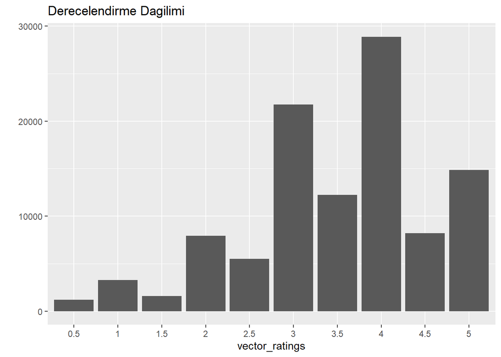

```r
vector_ratings <- vector_ratings[vector_ratings != 0] # rating == 0 lar NA değerleridir.
vector_ratings <- factor(vector_ratings)

qplot(vector_ratings) +
  ggtitle("Derecelendirme Dagilimi")
```

Goruldugu uzere, filmlerin cogu 3 veya daha yuksek bir puanla derecelendiriliyor. En yaygin derecelendirme degeri ise 4'tur.

## En Iyi Filmlerin Goruntulenme Sayisi

```r
views_per_movie <- colCounts(ratingmat) # her film icin goruntuleme sayisi

table_views <- data.frame(movie = names(views_per_movie),
                          views = views_per_movie) # gorunumler icin tablo olustur
table_views <- table_views[order(table_views$views,
                                 decreasing = TRUE), ] # goruntuleme sayisina gore sirala
table_views$title <- NA
for (i in 1:10325){
  table_views[i,3] <- as.character(subset(movies,
                                         movies$movieId == table_views[i,1])$title)
}

table_views[1:6,]
```

|  | movie | views | title |
| --- | --- | --- | --- |
| 296 | 296 | 325 | Pulp Fiction (1994) |
| 356 | 356 | 311 | Forrest Gump (1994) |
| 318 | 318 | 308 | Shawshank Redemption, The (1994) |
| 480 | 480 | 294 | Jurassic Park (1993) |
| 593 | 593 | 290 | Silence of the Lambs, The (1991) |
| 260 | 260 | 273 | Star Wars: Episode IV - A New Hope (1977) |

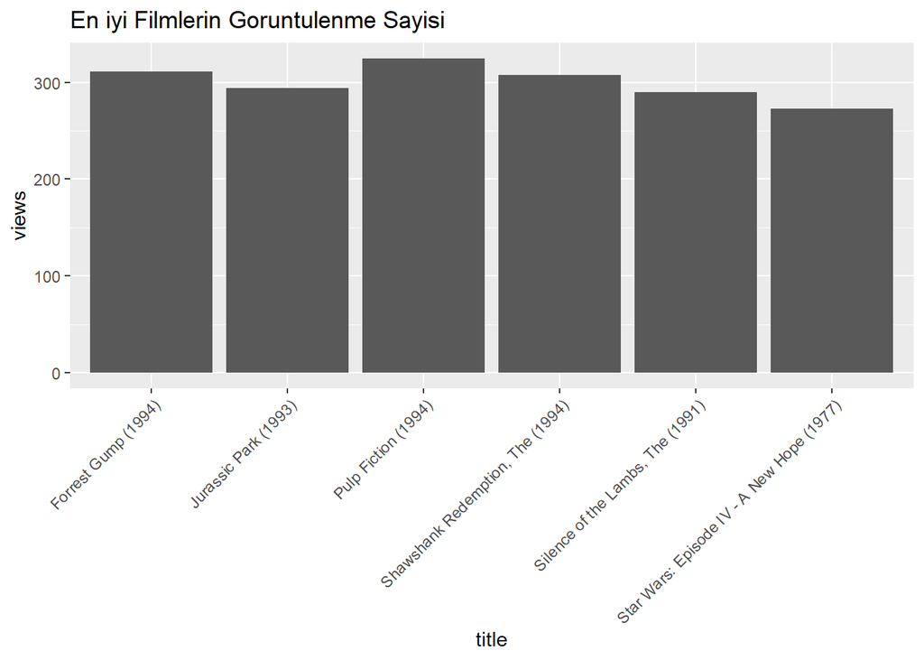

```r
ggplot(table_views[1:6, ], aes(x = title, y = views)) +
  geom_bar(stat="identity") +
  theme(axis.text.x = element_text(angle = 45, hjust = 1)) +
ggtitle("En iyi Filmlerin Goruntulenme Sayisi")
```

En cok izlenen filmin *Pulp Fiction(1994)* oldugu gorulmustur.

## Ortalama Film Derecelendirmesinin Dagilimi

Her bir filmin ortalama derecelendirmeleri hesaplanarak en yuksek puan alan filmler tanimlanir.

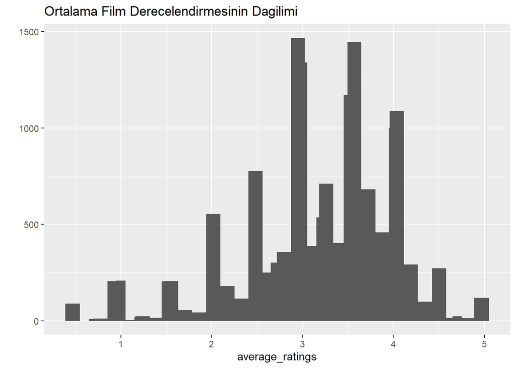

```r
average_ratings <- colMeans(ratingmat)

qplot(average_ratings) +
  stat_bin(binwidth = 0.1) +
  ggtitle("Ortalama Film Derecelendirmesinin Dagilimi")
```

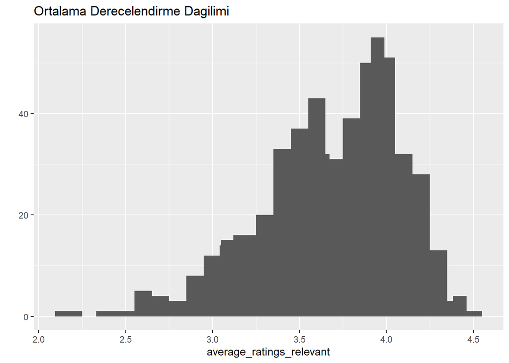

```r
average_ratings_relevant <- average_ratings[views_per_movie > 50]
qplot(average_ratings_relevant) +
  stat_bin(binwidth = 0.1) +
  ggtitle(paste("Ortalama Derecelendirme Dagilimi"))
```

Ilk tablo ortalama film derecelendirmesinin dagilimini gostermektedir. En yuksek deger 3 civarindadir ve derecesi 1 veya 5 olan birkac film vardir. Bu durum, bu filmlerin sadece bir kac kisiden 1 veya 5 derece almasiyla aciklanabilir.

Bu durumu ortadan kaldirmak ve daha guvenilir sonuclar elde etmek amaciyla goruntuleme sayisi 50'nin altinda olan filmler kaldirildi.

Ikinci tabloda tum siralamalar 2.16 ve 4.45 arasindadir. Yapilan islem sonucu uc noktalar degismistir. En yuksek deger 4 olmustur.

## Derecelendirme Matrisinin Isi Haritasi

Renkleri derecelendirmeleri temsil eden bir isi haritasi olusturulur ve tum derecelendirme matrisi gorsellestirilir. Matrisin her satiri bir kullaniciya, her bir sutun bir filme ve her bir hucre derecelendirmesine karsilik gelir.

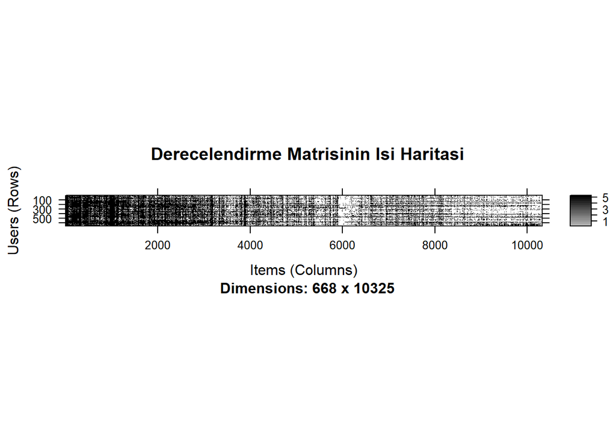

```r
  image(ratingmat, main = "Derecelendirme Matrisinin Isi Haritasi") # okunmasi zor ve cok fazla boyut
```

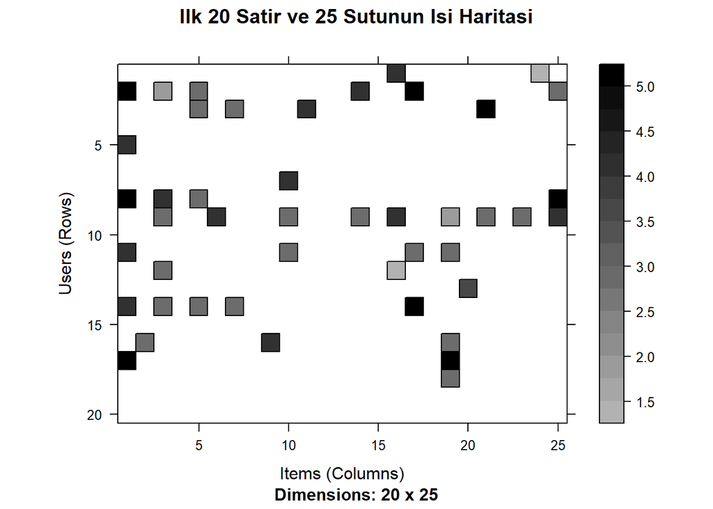

```r
image(ratingmat[1:20, 1:25], main = "Ilk 20 Satir ve 25 Sutunun Isi Haritasi")
```

Cok fazla kullanici ve oge oldugu icin ilk grafigin okunmasi zor olmustur. Ikinci grafik ilk 20 satir ve 25 sutundan olusturulmustur.

Bazi kullanicilar digerlerinden daha fazla film izlemistir. Bu nedenle, bazi rastgele kullanicilar ve ogeler goruntulenmek yerine, en alakali kullanicilar ve ogeler secmelidir. Bu yuzden sadece bircok film izleyen kullanicilar ve bircok kullanici tarafindan izlenen filmler gorsellestirilir.

En alakali kullanicilari ve filmleri tanimlamak ve secmek icin asagidaki adimlar izlenir:

1. Kullanici basina minimum film sayisi belirlenir.
2. Film basina minimum kullanici sayisi belirlenir.
3. Bu olcutlere uyan kullanicilar ve filmler secilir.

```r
min_n_movies <- quantile(rowCounts(ratingmat), 0.99)
min_n_users <- quantile(colCounts(ratingmat), 0.99)
print("Kullanici basina minimum film sayisi:")
```

```
## [1] "Kullanici basina minimum film sayisi:"
```

```r
min_n_movies
```

```
##     99%
## 1198.17
```

```r
print("Film basina minimum kullanici sayisi:")
```

```
## [1] "Film basina minimum kullanici sayisi:"
```

```r
min_n_users
```

```
## 99%
## 115
```

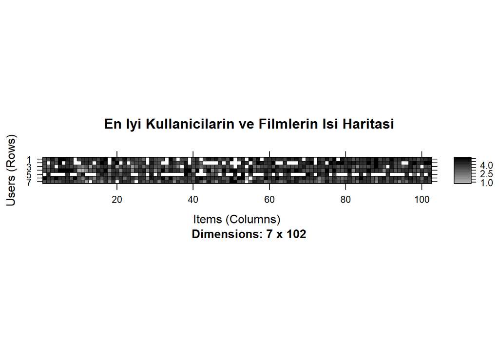

```r
image(ratingmat[rowCounts(ratingmat) > min_n_movies,
                 colCounts(ratingmat) > min_n_users],
main = "En Iyi Kullanicilarin ve Filmlerin Isi Haritasi")
```

Daha fazla film izleyen kullanicilar dikkate alinir. Bircok kullanici en iyi filmleri izlemistir. Isi haritasinin bazi sutunlari digerlerinden daha koyudur yani bu sutunlar en yuksek dereceli filmleri temsil eder, daha koyu satirlar ise daha yuksek derecelendirme yapan kullanicilari temsil eder.

## Veri Hazirlama

Dogru sonuc alabilmek icin en alakali veriler secilmelidir. En alakali verilerin secilmesi icin, derecelendirilen film basina minimum kullanici sayisi 50 ve film basina minimum goruntuleme sayisi 50 olarak tanimlanir

```r
ratings_movies <- ratingmat[rowCounts(ratingmat) > 50,
                             colCounts(ratingmat) > 50]
ratings_movies
```

```
## 420 x 447 rating matrix of class 'realRatingMatrix' with 38341 ratings.
```

En alakali veriler, toplam veri kumesine (668 kullaniciya ve 10325 film) kiyasla 420 kullanici ve 447 film icerir.

En alakali veriler kumesinde bulunan kullanicilarin ve filmlerin ilk yuzde 2'si gorsellestirilir.

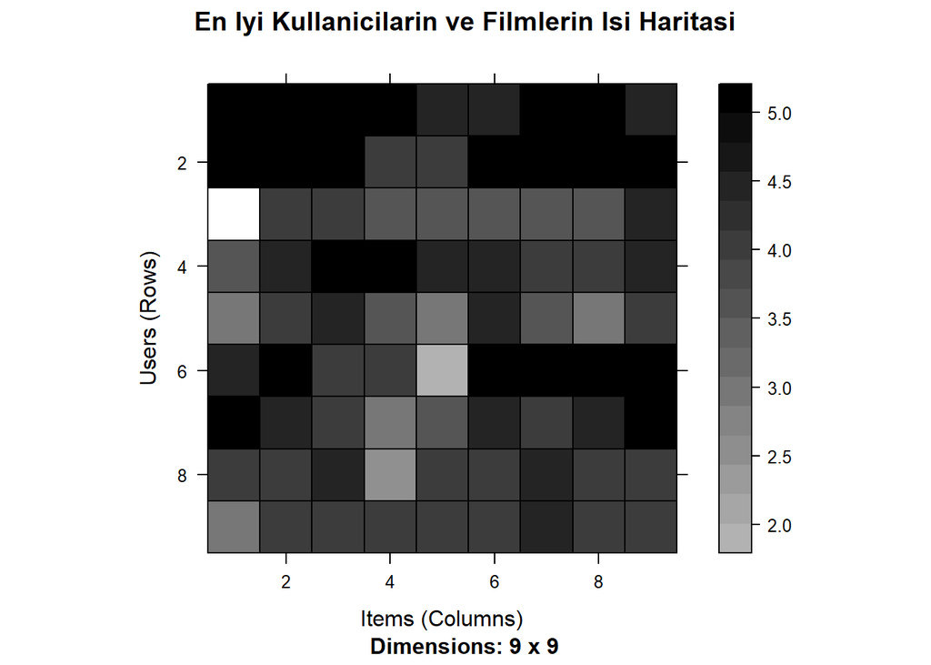

```r
min_movies <- quantile(rowCounts(ratings_movies), 0.98)
min_users <- quantile(colCounts(ratings_movies), 0.98)
image(ratings_movies[rowCounts(ratings_movies) > min_movies,
                     colCounts(ratings_movies) > min_users],
main = "En Iyi Kullanicilarin ve Filmlerin Isi Haritasi")
```

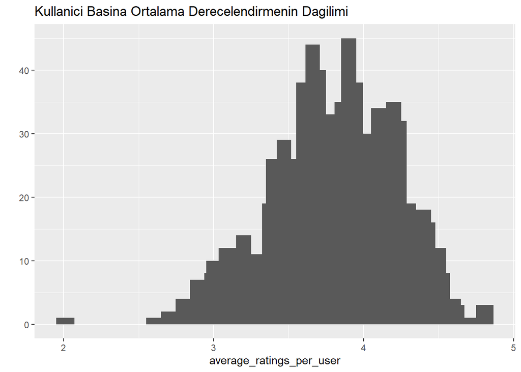

```r
average_ratings_per_user <- rowMeans(ratings_movies)
qplot(average_ratings_per_user) + stat_bin(binwidth = 0.1) +
  ggtitle("Kullanici Basina Ortalama Derecelendirmenin Dagilimi")
```

Isi haritasinda bazi satirlar digerlerinden daha koyudur. Bu, bazi kullanicilarin tum filmlere daha yuksek puan vermesi anlamina gelebilir. Ikinci grafikte ise goruldugu uzere, kullanici basina ortalama derecelendirmenin tum kullanicilar arasinda dagilimi cok degiskendir.

## Veriyi Normallestirme

Tum filmlere yuksek puan veren kullanicilar sonuclarin yaniltici olmasina sebep olabilir. Bu durumun ortadan kalkmasi icin her kullanicinin ortalama puani 0 olacak sekilde normallestirme yapilir.

```r
ratings_movies_norm <- normalize(ratings_movies)
sum(rowMeans(ratings_movies_norm) > 0.00001)
```

```
## [1] 0
```

En iyi filmler icin normallestirilmis matris gorsellestirilir. Veriler surekli oldugu icin gorsel renklenmistir.

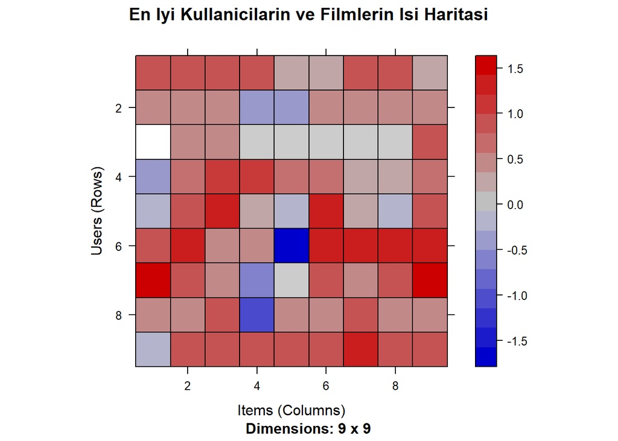

```r
image(ratings_movies_norm[rowCounts(ratings_movies_norm) > min_movies,
                          colCounts(ratings_movies_norm) > min_users],
main = "En Iyi Kullanicilarin ve Filmlerin Isi Haritasi")
```

## Verileri Ikileme

Bazi oneri modelleri ikili veriler uzerinde calisir, bu nedenle verileri ikililestirmek, yani yalnizca 0 ve 1 iceren bir tablo tanimlamak yararli olabilir. 0'lar eksik degerler veya kotu derecelendirme olarak degerlendirilir.

Bu projede ikililestirme ile ilgili iki farkli durum incelenir:

1. Kullanici filme oy verdiginde 1, aksi halde 0 olan bir matris tanimlanir ve derecelendirmeyle ilgili bilgiler kaybolur. Bu islemle film izleyip oy veren ve oy vermeyen kullanici gorulur.
2. Derecesi belirli bir esigin (ornegin 3) uzerinde veya ona esitse 1 ve aksi durumda 0 olan bir matris tanimlanir. Bu durumda, bir filme kotu bir derecelendirme vermek ve filmin derecelendirilmemesi(izlenmemis veya izlenipde derecelendirme yapilmamis) esdeger olur.

Her iki durum incelenir ve %5'lik kismi gorsellestirilir.

**1. Secenek**

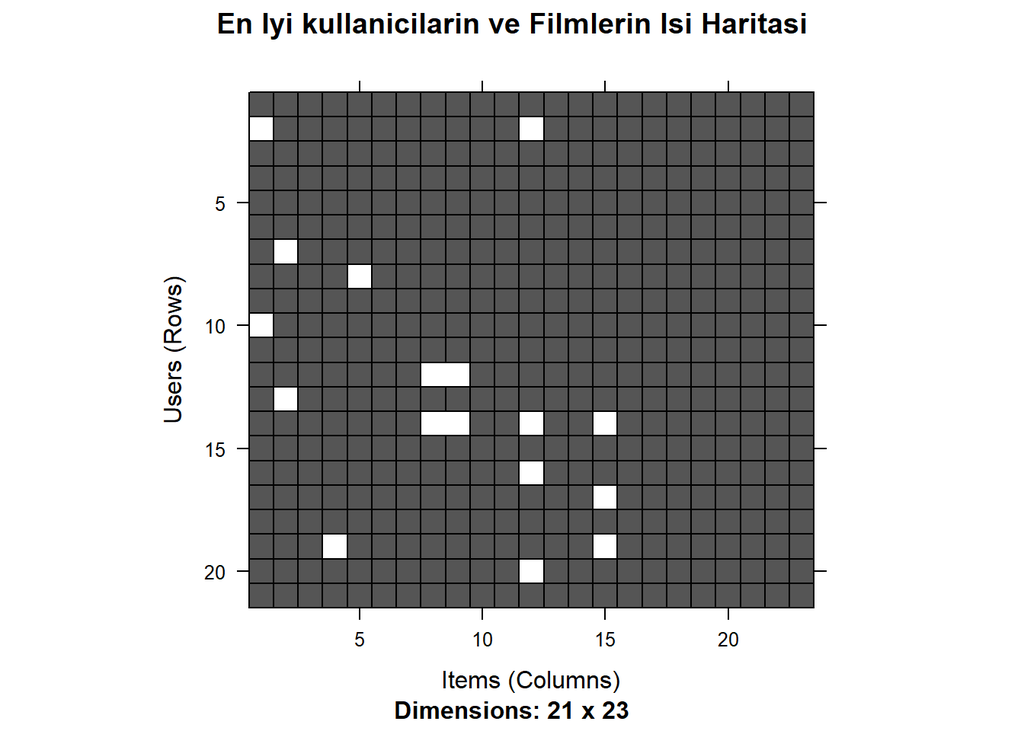

```r
ratings_movies_watched <- binarize(ratings_movies, minRating = 1)
min_movies_binary <- quantile(rowCounts(ratings_movies), 0.95)
min_users_binary <- quantile(colCounts(ratings_movies), 0.95)
image(ratings_movies_watched[rowCounts(ratings_movies) > min_movies_binary,
                             colCounts(ratings_movies) > min_users_binary],
main = "En Iyi kullanicilarin ve Filmlerin Isi Haritasi")
```

**2. Secenek**

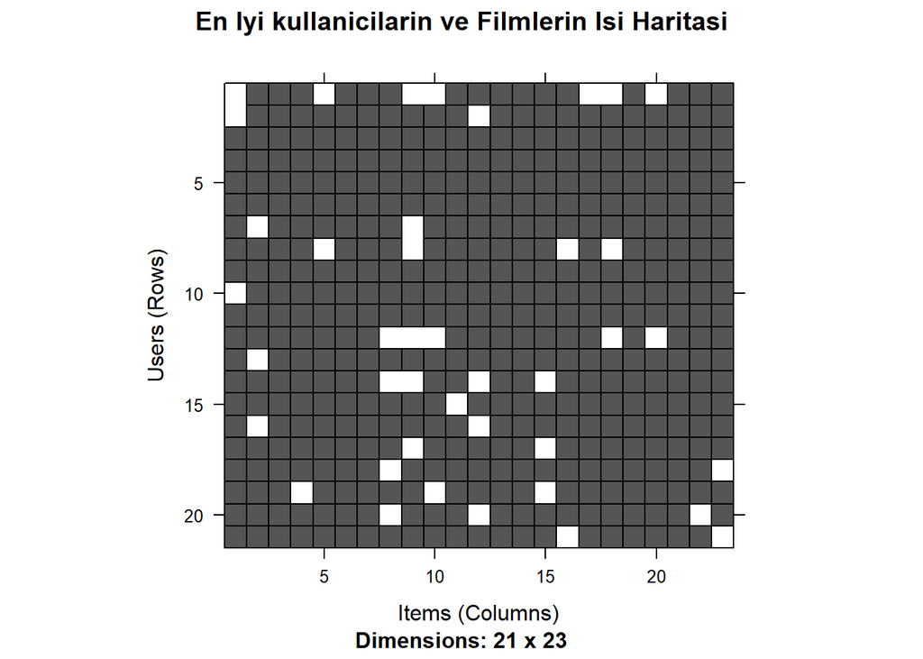

```r
ratings_movies_good <- binarize(ratings_movies, minRating = 3)
image(ratings_movies_good[rowCounts(ratings_movies) > min_movies_binary,
colCounts(ratings_movies) > min_users_binary],
main = "En Iyi kullanicilarin ve Filmlerin Isi Haritasi")
```

Ikinci isi haritasinda daha fazla beyaz hucre vardir, bu durum kullanicilar tarafindan izlenmeyen veya derecelendirilmeyen filmlerin daha fazla veya kotu derecelendirme yani belirledigimiz esigin (3) altinda derecelendirmeye sahip filmler oldugunu gosteriyor.

## IBCF Tabanli Isbirlikci Filtreleme Modeli

Isbirlikci filtreleme, farkli kullanicilar hakkindaki bilgileri dikkate alan bir tavsiye dalidir. "Isbirlikci" kelimesi, kullanicilarin ogeleri onermek icin birbirleriyle isbirligi yaptigi anlamina gelir. Aslinda, algoritmalar kullanici derecelendirmelerini ve tercihlerini dikkate alir.

## Train ve Test Setleri

Model, veri kumesinin % 80'ini train seti ve % 20'sini test seti olarak olusturulur.

```r
which_train <- sample(x = c(TRUE, FALSE),
                      size = nrow(ratings_movies),
                      replace = TRUE,
                      prob = c(0.8, 0.2))


recc_data_train <- ratings_movies[which_train, ]
recc_data_test <- ratings_movies[!which_train, ]
dim(recc_data_train )
```

```
## [1] 336 447
```

```r
dim(recc_data_test)
```

```
## [1]  84 447
```

## Oneri Modeli Olusturma

Bu modeldeki parametreler incelenir.Burada *k*, ilk adimda aralarindaki benzerliklerin hesaplanacagi islem sayisidir. Her oge icin, algoritma en cok benzer *k* ogelerini tanimlar ve numarayi saklar.*method*, varsayilan olarak *cosine* olan bir benzerlik islevidir (*pearson* olabilir). method = Cosine ve k=30 olan bir model olusturulur.

```r
recommender_models <- recommenderRegistry$get_entries(dataType ="realRatingMatrix")
recommender_models$IBCF_realRatingMatrix$parameters
```

```
## $k
## [1] 30
##
## $method
## [1] "Cosine"
##
## $normalize
## [1] "center"
##
## $normalize_sim_matrix
## [1] FALSE
##
## $alpha
## [1] 0.5
##
## $na_as_zero
## [1] FALSE
```

```r
recc_model <- Recommender(data = recc_data_train,
                          method = "IBCF",
                          parameter = list(k = 30))

recc_model
```

```
## Recommender of type 'IBCF' for 'realRatingMatrix'
## learned using 336 users.
```

```r
class(recc_model)
```

```
## [1] "Recommender"
## attr(,"package")
## [1] "recommenderlab"
```

Tavsiye modeli:

```r
model_details <- getModel(recc_model)

class(model_details$sim) #  benzerlik matrisi icerir
```

```
## [1] "dgCMatrix"
## attr(,"package")
## [1] "Matrix"
```

```r
dim(model_details$sim)
```

```
## [1] 447 447
```

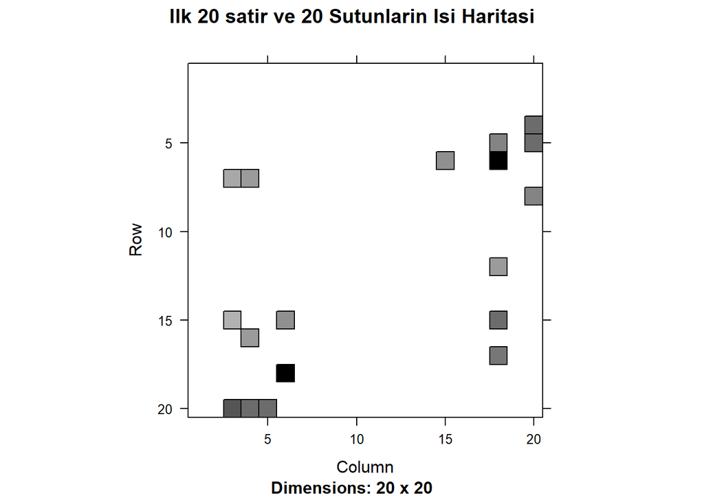

```r
n_items_top <- 20
image(model_details$sim[1:n_items_top, 1:n_items_top],
      main = "Ilk 20 satir ve 20 Sutunlarin Isi Haritasi")
```

*dgCMatrix* model tarafindan olusturulan bir benzerlik matrisidir. Boyutlari, oge sayisina esittir (447 x 447). Ilk 20 ogenin isi haritasi, bircok degerin 0'a esit oldugunu gosterir. Bunun nedeni, her satirin yalnizca 0'dan buyuk k (30) ogeleri icermesidir. Her sutun icin null olmayan ogelerin sayisi, karsilik gelen film, baska bir filmin ust k bolumune dahil edilmistir. Bu nedenle matris simetrik degildir.

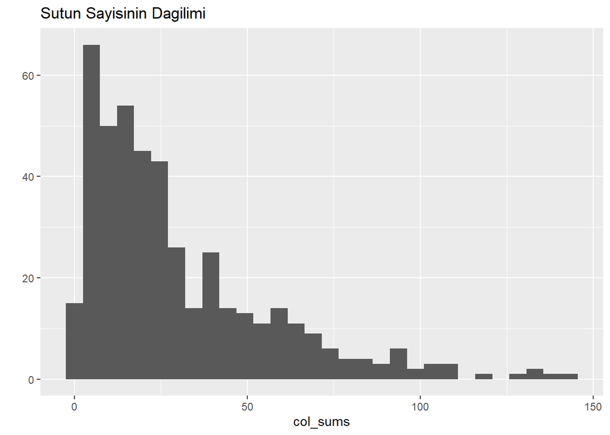

```r
col_sums <- colSums(model_details$sim > 0)
qplot(col_sums) + stat_bin(binwidth = 1) + ggtitle("Sutun Sayisinin Dagilimi")
```

Eleman sayisinin sutuna gore dagilim grafigi, digerlerine benzer birkac film oldugunu gosterir.

## Veri Kumesine Oneri Sistemi Uygulama

Test setindeki kullanicilara film onermek mumkun hale gelmistir, *n_recommended* , her kullaniciya onerilecek film sayisini belirten 10'a esitlenir.

Her kullanici icin, algoritma derecelendirilmis filmlerini cikarir. Her film icin, benzerlik matrisinden baslayarak tum benzer ogeleri tanimlar. Ardindan, algoritma her bir benzer ogeyi su sekilde siralar:

- Secilen filmle iliskili her izleme isleminin kullanici puanini cikarin. Derecelendirme agirlik olarak kullanilir.
- Secilen filmle iliskili her izleme ile ogenin benzerligini ayiklayin.
- Her agirligi ilgili benzerlikle carpin.
- Her seyi topla.

Ardindan, algoritma ilk 10 tavsiyeyi tanimlar:

```r
n_recommended <- 10 # her kullaniciya onerilecek oge sayisi

recc_predicted <- predict(object = recc_model,
                          newdata = recc_data_test,
                          n = n_recommended)
recc_predicted
```

```
## Recommendations as 'topNList' with n = 10 for 84 users.
```

Ilk kullanici icin onerilerin sonuclarini incelenir:

```r
recc_user_1 <- recc_predicted@items[[1]] #ilk kullanici icin oneri
movies_user_1 <- recc_predicted@itemLabels[recc_user_1]
movies_user_2 <- movies_user_1
for (i in 1:10){
  movies_user_2[i] <- as.character(subset(movies,
                                         movies$movieId == movies_user_1[i])$title)
}
movies_user_2
```

```
##  [1] "Grumpier Old Men (1995)"
##  [2] "Casino (1995)"
##  [3] "From Dusk Till Dawn (1996)"
##  [4] "Birdcage, The (1996)"
##  [5] "Natural Born Killers (1994)"
##  [6] "Clear and Present Danger (1994)"
##  [7] "Naked Gun 33 1/3: The Final Insult (1994)"
##  [8] "Cliffhanger (1993)"
##  [9] "Fugitive, The (1993)"
## [10] "In the Line of Fire (1993)"
```

Her kullanici icin onerileri iceren bir matris tanimlamak da mumkundur. Ilk dort kullanici icin oneriler gorsellestirilir:

```r
recc_matrix <- sapply(recc_predicted@items,
                      function(x){ as.integer(colnames(ratings_movies)[x]) }) # her kullanici icin onerileri iceren matris

recc_matrix[,1:4]
```

```
##       [,1]  [,2] [,3] [,4]
##  [1,]    3   595    1 1374
##  [2,]   16  4022    5 3081
##  [3,]   70  2542    6  337
##  [4,]  141  2424   10 2424
##  [5,]  288   364   16  158
##  [6,]  349   784   39 3033
##  [7,]  370 54286   44 5010
##  [8,]  434  1625   48 1204
##  [9,]  457 63082  153 1370
## [10,]  474   380  185  733
```

Burada, sutunlar ilk 4 kullaniciyi, satirlar onerilen 10 filmin *movieId* degerlerini ifade eder.

En cok tavsiye edilen filmler belirlenir

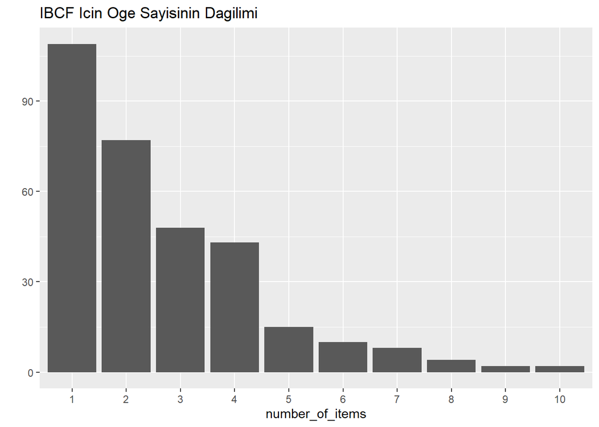

```r
number_of_items <- factor(table(recc_matrix))

chart_title <- "IBCF Icin Oge Sayisinin Dagilimi"
qplot(number_of_items) + ggtitle(chart_title)
```

```r
number_of_items_sorted <- sort(number_of_items, decreasing = TRUE)
number_of_items_top <- head(number_of_items_sorted, n = 4)
table_top <- data.frame(as.integer(names(number_of_items_top)),
                       number_of_items_top)

for (i in 1:4){
  table_top[i,1] <- as.character(subset(movies,
                                         movies$movieId == table_top[i,1])$title)
}

colnames(table_top) <- c("Movie title", "No of items")
head(table_top)
```

|  | Movie title | No of items |
| --- | --- | --- |
| 3 | Grumpier Old Men (1995) | 10 |
| 16 | Casino (1995) | 10 |
| 48 | Pocahontas (1995) | 9 |
| 112 | Rumble in the Bronx (Hont faan kui) (1995) | 9 |

Filmlerin cogu sadece birkac kez tavsiye edilmistir ve birkac film 5 kereden fazla tavsiye edilmistir.

IBCF benzerlik matrisi bazinda urun onerir. Her oge icin, model k-en cok benzerini depolar.

## UBCF Tabanli Isbirlikci Filtreleme Modeli

Her yeni kullanici icin adimlar:

1. Her kullanicinin yenisine ne kadar benzedigi olculur. IBCF gibi populer benzerlik olculeri korelasyon ve kosinustur.
2. En benzer kullanici belirlenir. Secenekler :
   - En iyi k kullanicilari dikkate alinir (k-nearest_neighbors)
   - Benzerligi tanimlanmis bir esigin uzerinde olan kullanicilar dikkate alinir
3. Benzer kullanicilar tarafindan en cok derecelendirilen filmler derecelendirilir. Bu derecelendirme benzer kullanicilar arasindaki ortalama derecenlendirmedir ve yaklasimlari :
- Ortalama puani
- Agirliklarla benzerlikleri kullanarak agirlikli ortalama degerlendirmedir.
4. En cok oy alan filmler secilir

## Oneri Sistemi Olusturma:

UBCF modelin varsayilan parametreleri kontrol edilir. Burada *nn* bir dizi benzer kullanicidir ve *method* olarak *cosine* benzerlik islevi kullanilir. Parametreler varsayilan degerlerine birakilarak ve train seti kullanilarak tavsiye modeli olusturulur.

```r
recommender_models <- recommenderRegistry$get_entries(dataType ="realRatingMatrix")
recommender_models$UBCF_realRatingMatrix$parameters
```

```
## $method
## [1] "cosine"
##
## $nn
## [1] 25
##
## $sample
## [1] FALSE
##
## $weighted
## [1] TRUE
##
## $normalize
## [1] "center"
##
## $min_matching_items
## [1] 0
##
## $min_predictive_items
## [1] 0
```

```r
recc_model <- Recommender(data = recc_data_train, method = "UBCF")
recc_model
```

```
## Recommender of type 'UBCF' for 'realRatingMatrix'
## learned using 336 users.
```

```r
model_details <- getModel(recc_model)
#names(model_details)
model_details$data
```

```
## 336 x 447 rating matrix of class 'realRatingMatrix' with 30700 ratings.
## Normalized using center on rows.
```

## Tavsiye Modelini Test Setine Uygulamak

IBCF ile aynidir. Test setindeki her yeni kullanici icin 10 tavsiye belirlenir.

```r
n_recommended <- 10
recc_predicted <- predict(object = recc_model,
                          newdata = recc_data_test,
                          n = n_recommended)
recc_predicted
```

```
## Recommendations as 'topNList' with n = 10 for 84 users.
```

**Sonuclar**

Ilk 4 kullaniciya bakilir:

```r
recc_matrix <- sapply(recc_predicted@items,
                      function(x){ as.integer(colnames(ratings_movies)[x]) })
#dim(recc_matrix)
recc_matrix[, 1:4]
```

```
##       [,1] [,2]  [,3]  [,4]
##  [1,] 1784 1035  1250  1584
##  [2,]  442 5618 49530  1214
##  [3,] 1645 2268  3421  1573
##  [4,] 2167 3147 68157  1645
##  [5,] 2396 1183  1584  1343
##  [6,]  368 2791  1673  2324
##  [7,] 1573  265  1200 63082
##  [8,] 5010 6016  2324  1285
##  [9,] 1200  778   908  2997
## [10,] 8360  318   912 48516
```

Bu matris ilk 4 kullanici icin her filmin *movieId*sini verir.

Her filmin kac kez onerildigine bakilir ve histogrami cizilir.

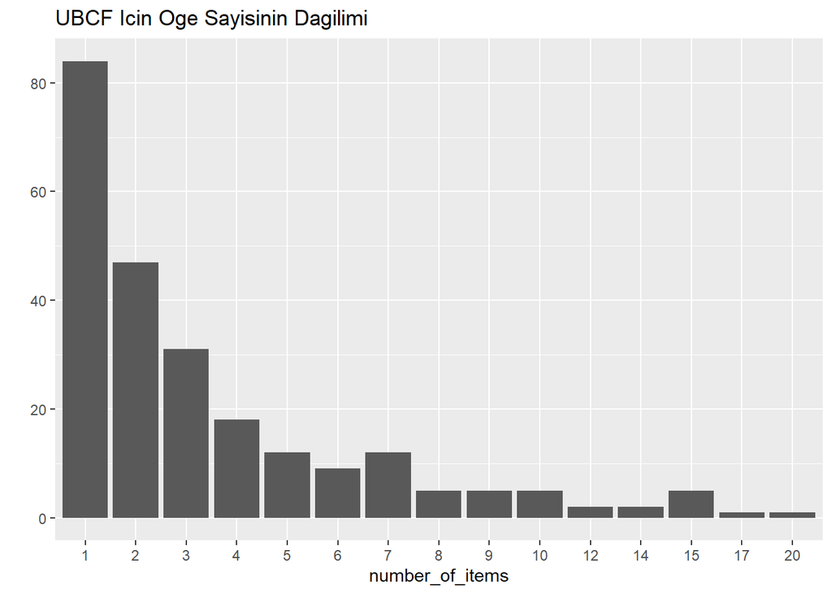

```r
number_of_items <- factor(table(recc_matrix))

chart_title <- "UBCF Icin Oge Sayisinin Dagilimi"
qplot(number_of_items) + ggtitle(chart_title)
```

IBCF ile karsilastirildiginda, dagilim daha uzun bir kuyruga sahiptir. Bu, digerlerinden daha sik onerilen bazi filmler oldugu anlamina gelir.

En iyi basliklara bakmak:

```r
number_of_items_sorted <- sort(number_of_items, decreasing = TRUE)
number_of_items_top <- head(number_of_items_sorted, n = 4)
table_top <- data.frame(as.integer(names(number_of_items_top)), number_of_items_top)

for (i in 1:4){
  table_top[i,1] <- as.character(subset(movies,
                                         movies$movieId == table_top[i,1])$title)
}
colnames(table_top) <- c("Movie title", "No of items")
head(table_top)
```

|  | Movie title | No of items |
| --- | --- | --- |
| 49530 | Blood Diamond (2006) | 20 |
| 1343 | Cape Fear (1991) | 17 |
| 920 | Gone with the Wind (1939) | 15 |
| 1252 | Chinatown (1974) | 15 |

UBCF'nin sonuclarini IBCF ile karsilastirmak, farkli algoritmalar hakkinda bazi yararli bilgiler bulunmasina yardimci olur. UBCF'nin ilk verilere erismesi gerekir. Tum veritabanini bellekte tutmasi gerektiginden, buyuk bir derecelendirme matrisinin varliginda iyi calismaz. Ayrica, benzerlik matrisini olusturmak cok fazla bilgi islem gucu ve zaman gerektirir.

Bununla birlikte, UBCF'nin dogrulugunun IBCF'den biraz daha dogru oldugu kanitlanmistir. Bu nedenle veri kumesi cok buyuk degilse iyi bir secenektir.

## Tavsiye Sistemlerini Degerlendirme

Bir oneri motoru olusturmaya karar verirken secim yapilabilecek birkac secenek vardir. Performanslari karsilastirmak ve en uygun modeli secmek icin su adimlar takip edilir:

- Performansi degerlendirmek icin verileri hazirlamak
- Bazi modellerin performanslarini degerlendirmek
- En iyi performans gosteren modelleri secmek
- Model parametrelerini optimize etmek

**Veriler Modellerin Degerlendirilmesi icin Hazirlanir**

Modeli degerlendirmek icin iki train ve test verisine ihtiyac vardir. Bunlari olusturmak icin birkac yontem vardir:

1. verileri train ve test setlerine bolme
2. onyukleme (Bootrstrapping)
3. k-katlama.

## Verileri Bolme

Verilerin train ve test setlerine bolunmesi genellikle 80/20 orani kullanilarak yapilir.

```r
percentage_training <- 0.8
```

Test setindeki her kullanici icin, oneriler olusturmak uzere kac oge kullanilacagi tanimlanmasi gerekir. Bunun icin, test edilecek hicbir ogeye sahip kullanici olmayacagindan emin olmak icin once kullanicilar tarafindan derecelendirilen minimum oge sayisi kontrol edilir.

```r
min(rowCounts(ratings_movies))
```

```
## [1] 8
```

```r
items_to_keep <- 5 #tavsiye edilecek oge sayisi
rating_threshold <- 3 # iyi kabul edilen minimum derecelendirmeye sahip esik
n_eval <- 1 #degerlendirme kac kez yapilir

eval_sets <- evaluationScheme(data = ratings_movies,
                              method = "split",
                              train = percentage_training,
                              given = items_to_keep,
                              goodRating = rating_threshold,
                              k = n_eval)
eval_sets
```

```
## Evaluation scheme with 5 items given
## Method: 'split' with 1 run(s).
## Training set proportion: 0.800
## Good ratings: >=3.000000
## Data set: 420 x 447 rating matrix of class 'realRatingMatrix' with 38341 ratings.
```

```r
getData(eval_sets, "train") # training set
```

```
## 336 x 447 rating matrix of class 'realRatingMatrix' with 29853 ratings.
```

```r
getData(eval_sets, "known") # onerileri olusturmak icin kullanilan ogelerle ayarlama
```

```
## 84 x 447 rating matrix of class 'realRatingMatrix' with 420 ratings.
```

```r
getData(eval_sets, "unknown") # onerileri test etmek icin kullanilan ogelerle ayarlanir
```

```
## 84 x 447 rating matrix of class 'realRatingMatrix' with 8068 ratings.
```

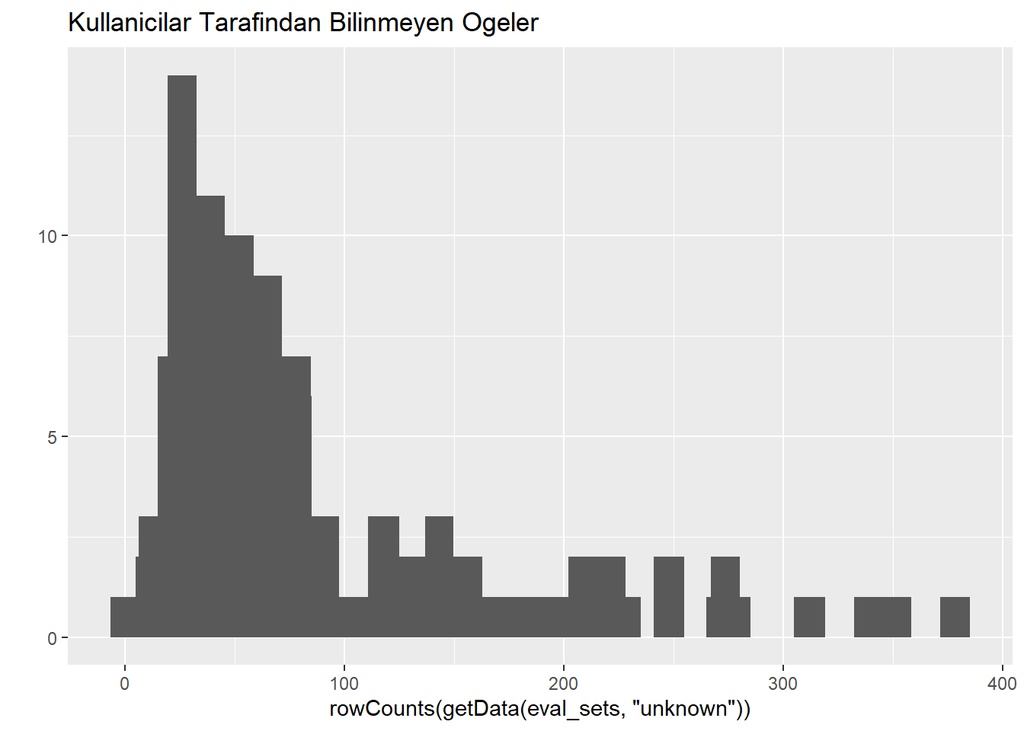

```r
qplot(rowCounts(getData(eval_sets, "unknown"))) +
  geom_histogram(binwidth = 10) +
  ggtitle("Kullanicilar Tarafindan Bilinmeyen Ogeler")
```

Kullanicilar tarafindan bilinmeyen ogeler cok degiskenlik gostermektedir.

## Verileri Onyukleme (Bootrstrapping)

Bootrstrapping, verileri bolmek icin baska bir yaklasimdir. Ayni kullanici bir kereden fazla orneklenebilir ve eger train seti daha oncekiyle ayni boyuta sahipse, test setinde daha fazla kullanici olacaktir.

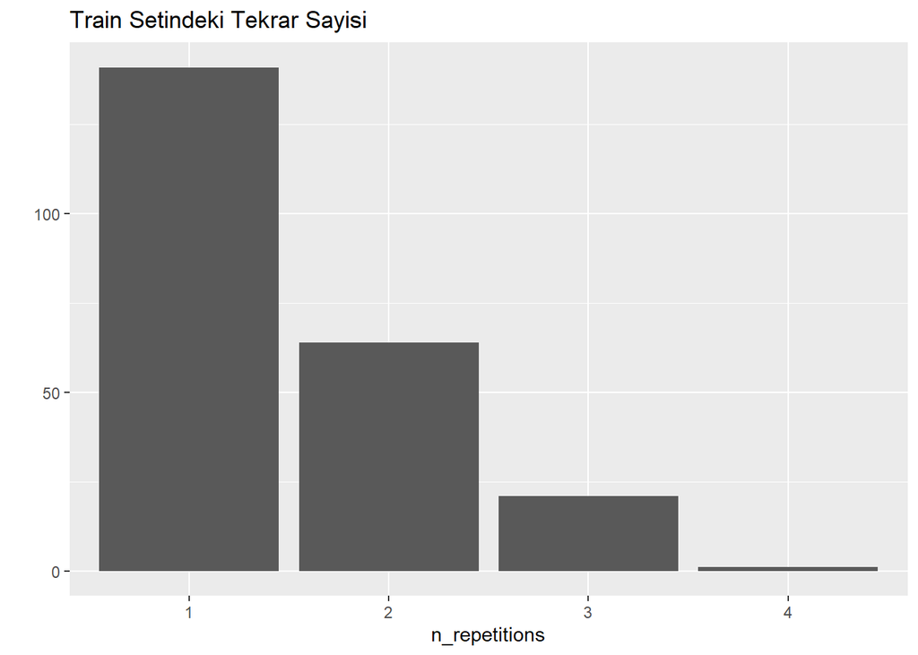

```r
eval_sets <- evaluationScheme(data = ratings_movies,
                              method = "bootstrap",
                              train = percentage_training,
                              given = items_to_keep,
                              goodRating = rating_threshold,
                              k = n_eval)

table_train <- table(eval_sets@runsTrain[[1]])
n_repetitions <- factor(as.vector(table_train))
qplot(n_repetitions) +
  ggtitle("Train Setindeki Tekrar Sayisi")
```

Grafikte kullanicilarin cogunun dort kereden daha az orneklendigi gosterilmistir.

## Modelleri Dogrulamak Icin Capraz Dogrulama Kullanma

Hesaplama acisindan daha agir olmasina ragmen, k-kat capraz gecerlilik yaklasimi en dogru yaklasimdir.

Bu yaklasim kullanilararak, veriler bazi parcalara ayrilir, test seti olarak bir parca cikarilir ve dogrulugu degerlendirilir. Ardindan, birbiriyle ortalama dogruluk hesaplanabilir.

```r
n_fold <- 4
eval_sets <- evaluationScheme(data = ratings_movies,
                              method = "cross-validation",
                              k = n_fold,
                              given = items_to_keep,
                              goodRating = rating_threshold)
size_sets <- sapply(eval_sets@runsTrain, length)
size_sets
```

```
## [1] 315 315 315 315
```

4-kat yaklasim kullanilarak, ayni boyutta 315 dort set olsun.

## Derecelendirmeleri Degerlendirme

Degerlendirme icin k-katlama yaklasimi kullanilir.

Ilk olarak, degerlendirme setleri yeniden tanimlanir, IBCF modelini olusturulur ve tahmin edilen derecelendirmelerle bir matris olusturulur.

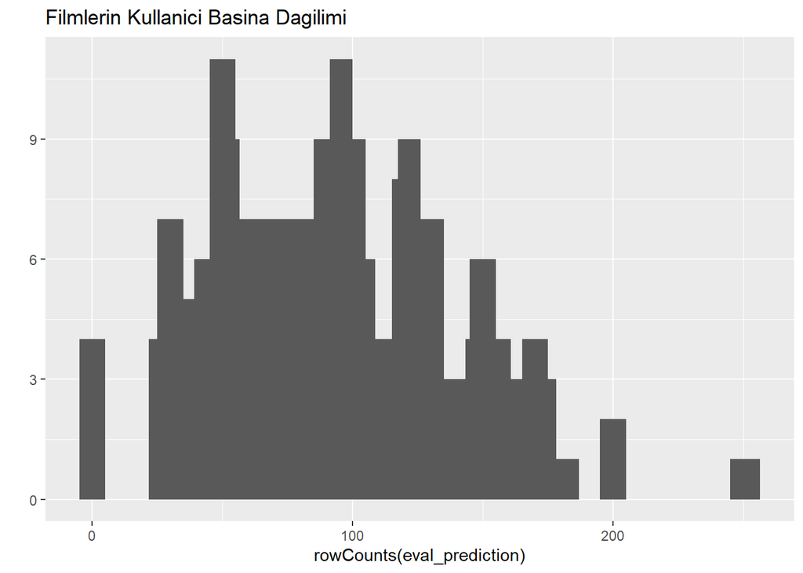

```r
eval_sets <- evaluationScheme(data = ratings_movies,
                              method = "cross-validation",
                              k = n_fold,
                              given = items_to_keep,
                              goodRating = rating_threshold)

model_to_evaluate <- "IBCF"
model_parameters <- NULL

eval_recommender <- Recommender(data = getData(eval_sets, "train"),
                                method = model_to_evaluate,
                                parameter = model_parameters)

items_to_recommend <- 10
eval_prediction <- predict(object = eval_recommender,
                           newdata = getData(eval_sets, "known"),
                           n = items_to_recommend,
                           type = "ratings")

qplot(rowCounts(eval_prediction)) +
  geom_histogram(binwidth = 10) +
  ggtitle("Filmlerin Kullanici Basina Dagilimi")
```

Yukaridaki goruntu, tahmin edilen derecelendirmeler matrisinde filmlerin kullanici basina dagilimini gostermektedir.

Her kullanici icin dogruluk olcumleri hesaplanir. RMSE'lerin cogu (Kok ortalama kare hatalari) 0,5 ile 1,8 araligindadir:

```
##           RMSE        MSE       MAE
## [1,] 1.3693064  1.8750000 1.1250000
## [2,] 0.6937105  0.4812342 0.5038024
## [3,] 0.9354143  0.8750000 0.7500000
## [4,] 3.2480764 10.5500000 2.5000000
## [5,] 0.6977407  0.4868421 0.4473684
## [6,] 1.0000000  1.0000000 1.0000000
```

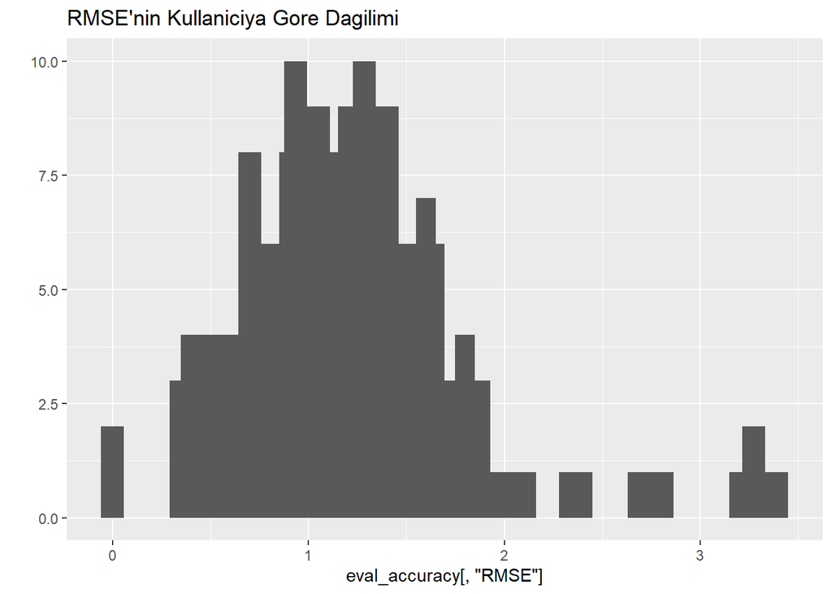

Tum model icin bir performans indeksine sahip olmak amaciyla, *byUser* ogesi FALSE olarak belirlenir ve ortalama indeksler hesaplanir:

```
##     RMSE      MSE      MAE
## 1.364599 1.862129 1.014919
```

Dogruluk olcutleri, ayni verilerin farkli modellerinin performansini karsilastirmak icin yararlidir.

**Onerilerin Degerlendirilmesi**

Dogrulugu olcmenin bir baska yolu, onerileri olumlu bir derecelendirmeye sahip satin alimlarla karsilastirmaktir. Bunun icin, *recommenderlab* kutuphanesinde onceden olusturulmus *evaluate* islevi kullanilabilir. Bu islev, her kullaniciya onerilecek ogelerin *n* sayisina bagli olarak onerici performansini degerlendirir. *n* dizisi n = seq (10, 100, 10) olarak kullanildi. Ortaya cikan performans matrisinin ilk satirlari asagida sunulmustur:

```r
results <- evaluate(x = eval_sets,
                    method = model_to_evaluate,
                    n = seq(10, 100, 10))
```

```
## IBCF run fold/sample [model time/prediction time]
##   1  [1.63sec/0.09sec]
##   2  [1.57sec/0.09sec]
##   3  [1.48sec/0.09sec]
##   4  [1.55sec/0.06sec]
```

```r
head(getConfusionMatrix(results)[[1]])
```

```
##          TP       FP       FN       TN precision     recall        TPR
## 10 1.942857  7.67619 75.66667 356.7143 0.2019802 0.02755426 0.02755426
## 20 3.628571 15.60952 73.98095 348.7810 0.1886139 0.04945990 0.04945990
## 30 5.114286 23.64762 72.49524 340.7429 0.1779234 0.06796499 0.06796499
## 40 6.676190 31.05714 70.93333 333.3333 0.1778607 0.08729286 0.08729286
## 50 8.047619 38.03810 69.56190 326.3524 0.1759356 0.10183810 0.10183810
## 60 9.342857 44.20952 68.26667 320.1810 0.1753316 0.11516306 0.11516306
##           FPR
## 10 0.02150462
## 20 0.04375461
## 30 0.06609775
## 40 0.08599572
## 50 0.10524783
## 60 0.12199256
```

Tum bolmelere ayni anda bir goz atmak icin TP, FP, FN ve TN sutunlarinin endeksleri ozetlenir:

*[Bu terimlerin aciklamasi](https://medium.com/@sengul_krdrl/hata-matrisini-anlamak-7035b7921c0f)*

```r
columns_to_sum <- c("TP", "FP", "FN", "TN")
indices_summed <- Reduce("+", getConfusionMatrix(results))[, columns_to_sum]
head(indices_summed)
```

```
##           TP        FP       FN       TN
## 10  6.942857  32.10476 295.3714 1433.581
## 20 13.438095  64.35238 288.8762 1401.333
## 30 19.638095  96.05714 282.6762 1369.629
## 40 25.857143 126.24762 276.4571 1339.438
## 50 31.514286 155.07619 270.8000 1310.610
## 60 36.638095 182.23810 265.6762 1283.448
```

Son olarak, ROC ve Precision-recall egrileri cizdirilir:

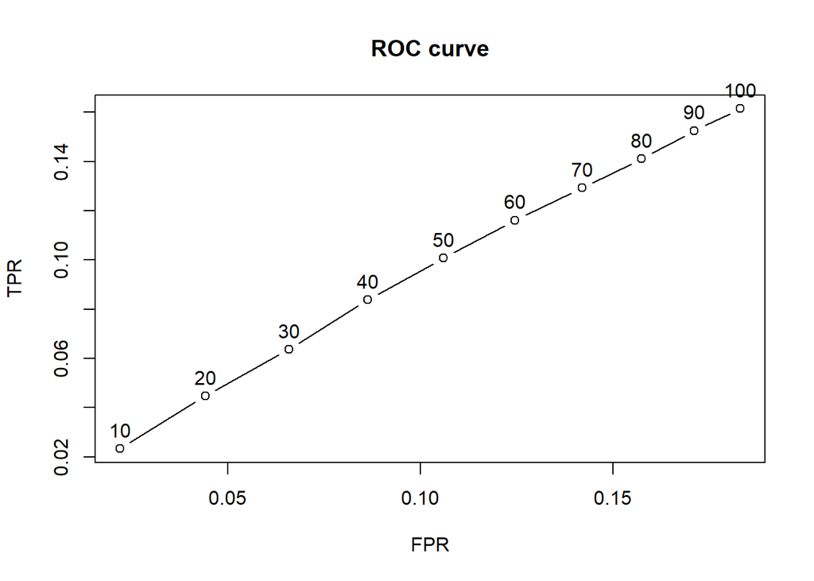

```r
plot(results, annotate = TRUE, main = "ROC curve")
```

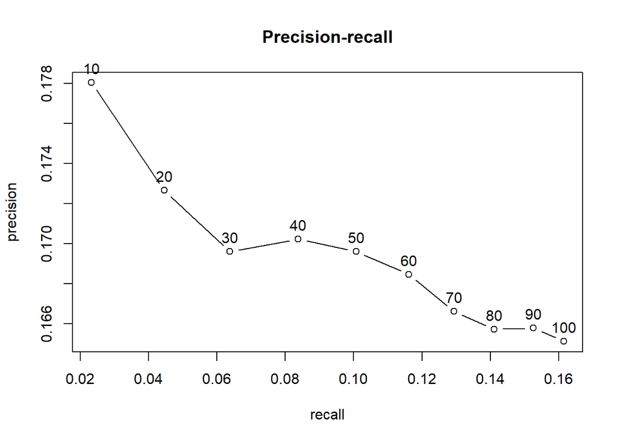

```r
plot(results, "prec/rec", annotate = TRUE, main = "Precision-recall")
```

## Modelleri Karsilastirma

Farkli modelleri karsilastirmak icin asagidaki tanimlamalar yapilir ve adimlar izlenir :

- Cosine'i mesafe fonksiyonu olarak kullanan oge tabanli ortak filtreleme
- Mesafe korelasyonu olarak Pearson korelasyonunu kullanarak madde bazli isbirlikci filtreleme
- Cosine'i mesafe fonksiyonu olarak kullanan kullanici tabanli ortak filtreleme
- Pearson korelasyonunu uzaklik fonksiyonu olarak kullanan kullanici tabanli ortak filtreleme
- Bir taban cizgisi olmasi icin rastgele oneriler

```r
models_to_evaluate <- list(
IBCF_cos = list(name = "IBCF",
                param = list(method = "cosine")),
IBCF_cor = list(name = "IBCF",
                param = list(method = "pearson")),
UBCF_cos = list(name = "UBCF",
                param = list(method = "cosine")),
UBCF_cor = list(name = "UBCF",
                param = list(method = "pearson")),
random = list(name = "RANDOM", param=NULL)
)
```

Onerilen filmler icin (n_recommendations <- c(1, 5, seq(10, 100, 10))) sayi kumesi tanimlanir.

```r
n_recommendations <- c(1, 5, seq(10, 100, 10))
list_results <- evaluate(x = eval_sets,
                         method = models_to_evaluate,
                         n = n_recommendations)
```

```
## IBCF run fold/sample [model time/prediction time]
##   1  [2.02sec/0.08sec]
##   2  [1.48sec/0.08sec]
##   3  [1.49sec/0.09sec]
##   4  [1.49sec/0.42sec]
## IBCF run fold/sample [model time/prediction time]
##   1  [2.02sec/0.08sec]
##   2  [2sec/0.1sec]
##   3  [2.03sec/0.06sec]
##   4  [2.36sec/0.1sec]
## UBCF run fold/sample [model time/prediction time]
##   1  [0.01sec/0.63sec]
##   2  [0.02sec/0.58sec]
##   3  [0.01sec/0.61sec]
##   4  [0sec/0.61sec]
## UBCF run fold/sample [model time/prediction time]
##   1  Error in neighbors[, x] : yanlış sayıda boyut
## RANDOM run fold/sample [model time/prediction time]
##   1  [0sec/0.18sec]
##   2  [0sec/0.13sec]
##   3  [0sec/0.14sec]
##   4  [0.01sec/0.13sec]
```

```r
sapply(list_results, class) == "evaluationResults"
```

```
## IBCF_cos IBCF_cor UBCF_cos   random
##     TRUE     TRUE     TRUE     TRUE
```

Asagidaki tabloda ornek olarak Kosinus mesafeli IBCF icin performans degerlendirme matrisinin ilk satirlari gosterilmektedir:

```r
avg_matrices <- lapply(list_results, avg)
head(avg_matrices$IBCF_cos[, 5:8])
```

```
##    precision      recall         TPR         FPR
## 1  0.1613032 0.002134229 0.002134229 0.002245296
## 5  0.1860302 0.012531651 0.012531651 0.010899424
## 10 0.1780366 0.023280090 0.023280090 0.021982876
## 20 0.1726570 0.044634183 0.044634183 0.044096000
## 30 0.1696075 0.063719633 0.063719633 0.065811086
## 40 0.1702207 0.083785827 0.083785827 0.086336801
```

## En Uygun Modeli Belirleme

Modeller ROC egrileri ve Precision-recall egrilerini gosteren bir grafik olusturularak karsilastirilir.

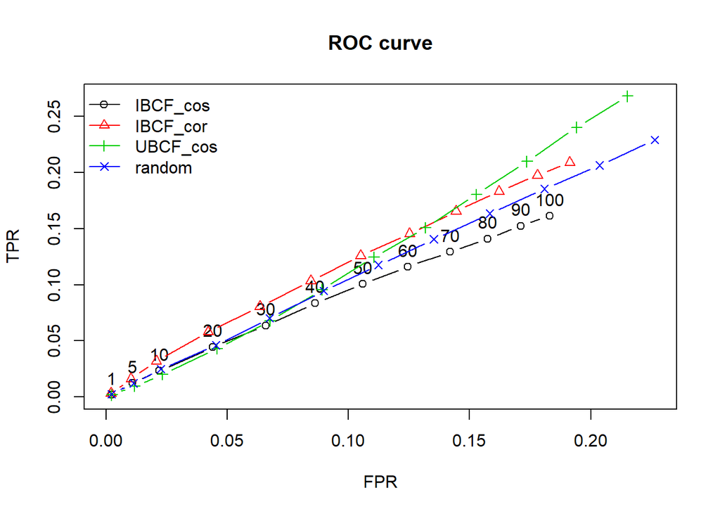

```r
plot(list_results, annotate = 1, legend = "topleft")
title("ROC curve")
```

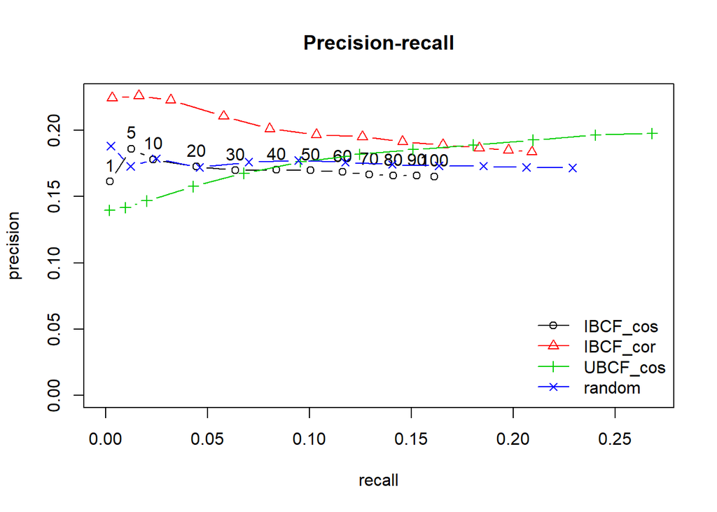

```r
plot(list_results, "prec/rec", annotate = 1, legend = "bottomright")
title("Precision-recall")
```

Iyi bir performans indeksi egrinin altindaki alandir (AUC), yani ROC egrisinin altindaki alandir. Hesaplamadan bile, grafik en yuksegin kosinus mesafesi olan UBCF oldugunu gosterir, bu yuzden en iyi performans gosteren tekniktir.

Kosinus mesafeli UBCF en iyi modeldir. Sistemin ana amacinin ne olduguna bagli olarak, tavsiye edilecek uygun sayida oge tanimlanmalidir.

```r
vector_k <- c(5, 10, 20, 30, 40)
models_to_evaluate <- lapply(vector_k, function(k){
  list(name = "IBCF",
       param = list(method = "cosine", k = k))
})
names(models_to_evaluate) <- paste0("IBCF_k_", vector_k)
```

[figure not shown]

```r
plot(list_results, annotate = 1, legend = "topleft")
title("ROC curve")
```

[figure not shown]

```r
plot(list_results, "prec/rec", annotate = 1, legend = "bottomright")
title("Precision-recall")
```

## UBCF Modelini Gosteren Cevrimici ShinyApp Uygulamasi

R'deki Shiny paketini kullanilarak tavsiye sistemi icin bir web uygulamasi olusturuldu.Bu web uygulamasinda, *kullanici tabanli isbirlikci yaklasim* tarafindan olusturulan tavsiye sistemi sunuldu. Bu yaklasim, bu proje icin yapilan degerlendirmeye dayanarak en iyi performans gosteren yontem *kullanici tabanli isbirlikci yaklasim* oldugu icin kullanilmistir.

Web uygulamasina buradan ulasabilirsiniz. **[FilmOneriSistemi](https://filmonerisistemi-nisero.shinyapps.io/Film_Oneri_Sistemleri/?_ga=2.105718464.230254219.1593824124-369299993.1593824124)**

## KAYNAKÇA :

- **(https://cran.r-project.org/web/packages/recosystem/vignettes/introduction.html)**
- **(https://sifter.org/~simon/journal/20061211.html)**
- **(https://rpubs.com/vsi/movielens)**
- **(https://rpubs.com/jeknov/movieRec)**
- **(https://data-flair.training/blogs/data-science-r-movie-recommendation/)**
- **(http://rstudio-pubs-static.s3.amazonaws.com/248530_18970dc8eb4046a6b4f2fba987fe2a50.html)**
- **(https://github.com/danmalter/Movielense)**

**Shiny APP**

- **[Shiny Uyelik](https://www.shinyapps.io/)**
- **[Rstudio-Shiny](https://shiny.rstudio.com/)**

## Projemiz Ile Ilgili Sorulacak Sorular

1.Oneri sistemimizde hangi filtreleme sistemini kullandik?Aciklayiniz?

2.Benzerlik icin hangi methodlar kullanilabilir,bu projede hangi method kullanilmistir?

3.Oneri sistemi modelini degerlerlendirmek icin kullanilan yontemler nelerdir?

4.En iyi modeli bulmak icin hangi grafiksel yontem kullanilir ?

5.Shiny app kullanicilar icin nasil acik hale getirilir?